# EPL_20_21 - Python Data Analysis

## By Jubril Okunade

- Introduction
- Data wrangling
- Exploration and Visualization
- Conclusion
- Limitation
- Glossary

# Introduction

In this section of the report, I will give a short introduction about the dataset that I'll be performing my analysis on. At the close of this section, I will put forward some questions which will guide my analysis.

The dataset I will be using is the `EPL_20_21` dataset which contains a collection of basic but crucial stats of the English Premier League 2020-21 season. The dataset has all the players that played in the EPL and their standard stats such as Goals, Assists, xG, xA, Passes Attempted, Pass Accuracy and some other important stats.

## Questions to be investigated in this dataset:

- Which team has the youngest squad?
- Which non-english countries had the most players in the league?
- The teams with the worst disciplinary record for the season?
- Which outfield players played the most minutes?
- Which teams received the most penalties?

  > I will be answering these questions through my analysis of the dataset.

```python
# I will start by importing the packages to be used for this analysis.
import pandas as pd
import numpy as np
import matplotlib.pyplot as plt
import seaborn as sns
%matplotlib inline
```

Now that all the packages have been imported, we can move on to the Data Wrangling section.

# Data Wrangling

This section involves the following:

- Loading the **EPL_20_21** dataset.
- Assessing the **EPL_20_21** dataset to identify any issues with it's quality or structure.
- Cleaning any issues highlighted in the assessment stage.

## Loading the dataset

```python
# load the dataset into the variable 'data'
data = pd.read_csv('EPL_20_21.csv')
```

## Assessment

### Visual assessment

```python
# visually assess the dataset by doing a quick look-through of the dataset.
data
```

|  | Name | Club | Nationality | Position | Age | Matches | Starts | Mins | Goals | Assists | Passes_Attempted | Perc_Passes_Completed | Penalty_Goals | Penalty_Attempted | xG | xA | Yellow_Cards | Red_Cards |
| --- | --- | --- | --- | --- | --- | --- | --- | --- | --- | --- | --- | --- | --- | --- | --- | --- | --- | --- |
| 0 | Mason Mount | Chelsea | ENG | MF,FW | 21 | 36 | 32 | 2890 | 6 | 5 | 1881 | 82.3 | 1 | 1 | 0.21 | 0.24 | 2 | 0 |
| 1 | Edouard Mendy | Chelsea | SEN | GK | 28 | 31 | 31 | 2745 | 0 | 0 | 1007 | 84.6 | 0 | 0 | 0.00 | 0.00 | 2 | 0 |
| 2 | Timo Werner | Chelsea | GER | FW | 24 | 35 | 29 | 2602 | 6 | 8 | 826 | 77.2 | 0 | 0 | 0.41 | 0.21 | 2 | 0 |
| 3 | Ben Chilwell | Chelsea | ENG | DF | 23 | 27 | 27 | 2286 | 3 | 5 | 1806 | 78.6 | 0 | 0 | 0.10 | 0.11 | 3 | 0 |
| 4 | Reece James | Chelsea | ENG | DF | 20 | 32 | 25 | 2373 | 1 | 2 | 1987 | 85.0 | 0 | 0 | 0.06 | 0.12 | 3 | 0 |
| ... | ... | ... | ... | ... | ... | ... | ... | ... | ... | ... | ... | ... | ... | ... | ... | ... | ... | ... |
| 527 | Lys Mousset | Sheffield United | FRA | FW,MF | 24 | 11 | 2 | 296 | 0 | 0 | 50 | 80.0 | 0 | 0 | 0.22 | 0.10 | 0 | 0 |
| 528 | Jack O'Connell | Sheffield United | ENG | DF | 26 | 2 | 2 | 180 | 0 | 0 | 77 | 77.9 | 0 | 0 | 0.00 | 0.00 | 0 | 0 |
| 529 | Iliman Ndiaye | Sheffield United | FRA | MF | 21 | 1 | 0 | 12 | 0 | 0 | 3 | 100.0 | 0 | 0 | 0.00 | 0.00 | 0 | 0 |
| 530 | Antwoine Hackford | Sheffield United | ENG | DF,FW | 16 | 1 | 0 | 11 | 0 | 0 | 1 | 100.0 | 0 | 0 | 1.16 | 0.00 | 0 | 0 |
| 531 | Femi Seriki | Sheffield United | ENG | DF | 17 | 1 | 0 | 1 | 0 | 0 | 0 | -1.0 | 0 | 0 | 0.00 | 0.00 | 0 | 0 |

532 rows × 18 columns

- After doing a quick check of the dataset, we can see it contains **532** rows and **18** columns. It contains columns such as Nationality, Age, Position, Club, Name and some other important information about the players.

### Programatic Assessment

```python
# For programatic assessment, I will be using code to assess the dataset

# check the first 5 rows
data.head()
```

|  | Name | Club | Nationality | Position | Age | Matches | Starts | Mins | Goals | Assists | Passes_Attempted | Perc_Passes_Completed | Penalty_Goals | Penalty_Attempted | xG | xA | Yellow_Cards | Red_Cards |
| --- | --- | --- | --- | --- | --- | --- | --- | --- | --- | --- | --- | --- | --- | --- | --- | --- | --- | --- |
| 0 | Mason Mount | Chelsea | ENG | MF,FW | 21 | 36 | 32 | 2890 | 6 | 5 | 1881 | 82.3 | 1 | 1 | 0.21 | 0.24 | 2 | 0 |
| 1 | Edouard Mendy | Chelsea | SEN | GK | 28 | 31 | 31 | 2745 | 0 | 0 | 1007 | 84.6 | 0 | 0 | 0.00 | 0.00 | 2 | 0 |
| 2 | Timo Werner | Chelsea | GER | FW | 24 | 35 | 29 | 2602 | 6 | 8 | 826 | 77.2 | 0 | 0 | 0.41 | 0.21 | 2 | 0 |
| 3 | Ben Chilwell | Chelsea | ENG | DF | 23 | 27 | 27 | 2286 | 3 | 5 | 1806 | 78.6 | 0 | 0 | 0.10 | 0.11 | 3 | 0 |
| 4 | Reece James | Chelsea | ENG | DF | 20 | 32 | 25 | 2373 | 1 | 2 | 1987 | 85.0 | 0 | 0 | 0.06 | 0.12 | 3 | 0 |

```python
# check the last 5 rows
data.tail()
```

|  | Name | Club | Nationality | Position | Age | Matches | Starts | Mins | Goals | Assists | Passes_Attempted | Perc_Passes_Completed | Penalty_Goals | Penalty_Attempted | xG | xA | Yellow_Cards | Red_Cards |
| --- | --- | --- | --- | --- | --- | --- | --- | --- | --- | --- | --- | --- | --- | --- | --- | --- | --- | --- |
| 527 | Lys Mousset | Sheffield United | FRA | FW,MF | 24 | 11 | 2 | 296 | 0 | 0 | 50 | 80.0 | 0 | 0 | 0.22 | 0.1 | 0 | 0 |
| 528 | Jack O'Connell | Sheffield United | ENG | DF | 26 | 2 | 2 | 180 | 0 | 0 | 77 | 77.9 | 0 | 0 | 0.00 | 0.0 | 0 | 0 |
| 529 | Iliman Ndiaye | Sheffield United | FRA | MF | 21 | 1 | 0 | 12 | 0 | 0 | 3 | 100.0 | 0 | 0 | 0.00 | 0.0 | 0 | 0 |
| 530 | Antwoine Hackford | Sheffield United | ENG | DF,FW | 16 | 1 | 0 | 11 | 0 | 0 | 1 | 100.0 | 0 | 0 | 1.16 | 0.0 | 0 | 0 |
| 531 | Femi Seriki | Sheffield United | ENG | DF | 17 | 1 | 0 | 1 | 0 | 0 | 0 | -1.0 | 0 | 0 | 0.00 | 0.0 | 0 | 0 |

```python
# use the info() function
data.info()
```

```
<class 'pandas.core.frame.DataFrame'>
RangeIndex: 532 entries, 0 to 531
Data columns (total 18 columns):
 #   Column                 Non-Null Count  Dtype
---  ------                 --------------  -----
 0   Name                   532 non-null    object
 1   Club                   532 non-null    object
 2   Nationality            532 non-null    object
 3   Position               532 non-null    object
 4   Age                    532 non-null    int64
 5   Matches                532 non-null    int64
 6   Starts                 532 non-null    int64
 7   Mins                   532 non-null    int64
 8   Goals                  532 non-null    int64
 9   Assists                532 non-null    int64
 10  Passes_Attempted       532 non-null    int64
 11  Perc_Passes_Completed  532 non-null    float64
 12  Penalty_Goals          532 non-null    int64
 13  Penalty_Attempted      532 non-null    int64
 14  xG                     532 non-null    float64
 15  xA                     532 non-null    float64
 16  Yellow_Cards           532 non-null    int64
 17  Red_Cards              532 non-null    int64
dtypes: float64(3), int64(11), object(4)
memory usage: 74.9+ KB
```

```python
# check for descriptive statistics
data.describe()
```

|  | Age | Matches | Starts | Mins | Goals | Assists | Passes_Attempted | Perc_Passes_Completed | Penalty_Goals | Penalty_Attempted | xG | xA | Yellow_Cards | Red_Cards |
| --- | --- | --- | --- | --- | --- | --- | --- | --- | --- | --- | --- | --- | --- | --- |
| count | 532.000000 | 532.000000 | 532.000000 | 532.000000 | 532.000000 | 532.000000 | 532.000000 | 532.000000 | 532.000000 | 532.000000 | 532.000000 | 532.000000 | 532.000000 | 532.000000 |
| mean | 25.500000 | 19.535714 | 15.714286 | 1411.443609 | 1.853383 | 1.287594 | 717.750000 | 77.823872 | 0.191729 | 0.234962 | 0.113289 | 0.072650 | 2.114662 | 0.090226 |
| std | 4.319404 | 11.840459 | 11.921161 | 1043.171856 | 3.338009 | 2.095191 | 631.372522 | 13.011631 | 0.850881 | 0.975818 | 0.148174 | 0.090072 | 2.269094 | 0.293268 |
| min | 16.000000 | 1.000000 | 0.000000 | 1.000000 | 0.000000 | 0.000000 | 0.000000 | -1.000000 | 0.000000 | 0.000000 | 0.000000 | 0.000000 | 0.000000 | 0.000000 |
| 25% | 22.000000 | 9.000000 | 4.000000 | 426.000000 | 0.000000 | 0.000000 | 171.500000 | 73.500000 | 0.000000 | 0.000000 | 0.010000 | 0.000000 | 0.000000 | 0.000000 |
| 50% | 26.000000 | 21.000000 | 15.000000 | 1345.000000 | 1.000000 | 0.000000 | 573.500000 | 79.200000 | 0.000000 | 0.000000 | 0.060000 | 0.050000 | 2.000000 | 0.000000 |
| 75% | 29.000000 | 30.000000 | 27.000000 | 2303.500000 | 2.000000 | 2.000000 | 1129.500000 | 84.625000 | 0.000000 | 0.000000 | 0.150000 | 0.110000 | 3.000000 | 0.000000 |
| max | 38.000000 | 38.000000 | 38.000000 | 3420.000000 | 23.000000 | 14.000000 | 3214.000000 | 100.000000 | 9.000000 | 10.000000 | 1.160000 | 0.900000 | 12.000000 | 2.000000 |

- From the data above, we can see that the average age for the league was around age 26. We can also see that on average most players got around 1411 mintues of gametime but this is heavily skewed by goalkeepers who usually play the full 90 mintues for almost every single game.

### Cleaning

- Assessment of the dataset brought up no issues that required cleaning.

```python
# Create a copy of the dataset and name it 'df'
df = data.copy()
```

# Exploration and Visualization

### Research Question 1: Which team has the youngest squad.

For this question, I will be doing the following:

- We will examine the Age column.
- Plot a histogram of the Age column
- Plot a barchart showing the team with the youngest sqaud.

```python
# examine the age column
df.Age.describe()
```

```
count    532.000000
mean      25.500000
std        4.319404
min       16.000000
25%       22.000000
50%       26.000000
75%       29.000000
max       38.000000
Name: Age, dtype: float64
```

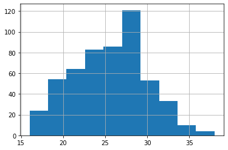

```python
# create a histogram of the age column
df.Age.hist()
```

```python
# Find the average age of each club and sort in ascending order
# assign the sorted values to a variable 'Yng_squad'
Yng_squad = df.groupby('Club')['Age'].mean().sort_values()
```

```python
Yng_squad
```

```
Club
Manchester United          23.862069
Southampton                24.137931
Aston Villa                24.291667
Wolverhampton Wanderers    24.444444
Brighton                   24.555556
Sheffield United           24.814815
Arsenal                    24.965517
Fulham                     25.035714
Leeds United               25.347826
Everton                    25.413793
Liverpool FC               25.571429
Chelsea                    25.592593
Leicester City             25.592593
Tottenham Hotspur          25.625000
Manchester City            25.708333
Newcastle United           26.074074
West Bromwich Albion       26.766667
Burnley                    27.040000
West Ham United            27.500000
Crystal Palace             28.333333
Name: Age, dtype: float64
```

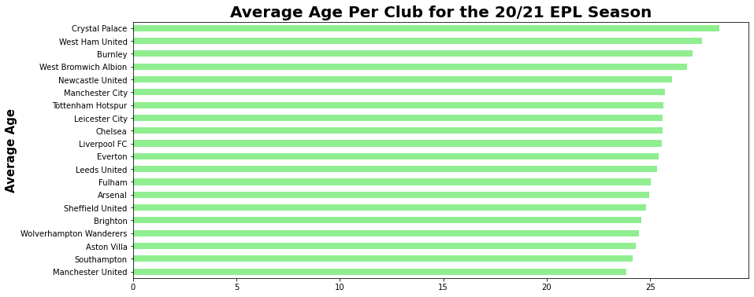

```python
# plot chart
plt.figure(figsize=(14,6))
Yng_squad.plot(kind='barh', color='lightgreen')
plt.title('Average Age Per Club for the 20/21 EPL Season',fontsize=20, fontweight='bold')
plt.ylabel('Average Age', fontsize=15, fontweight='bold')
plt.show()
```

### Insights observed:

- Manchester United had the youngest squad with an average age of 23.86, roughly 24 years.
- Crystal palace had the oldest squad with an average age of 28.33 roughly 28 years.

### Research Question 2: Which non-english countries had the most players in the league.

> This question will be addressed in the following ways:
> - Eamine the Nationality column.
> - Create a dataframe that excludes English players.
> - Use the created dataframe to plot a bar chart showing the Nationalities with the most players in the league.

```python
# Examine the Nationality clumn
df.Nationality.describe()
```

```
count     532
unique     59
top       ENG
freq      192
Name: Nationality, dtype: object
```

```python
# show the unique values
df.Nationality.unique()
```

```
array(['ENG', 'SEN', 'GER', 'ESP', 'FRA', 'ITA', 'BRA', 'CRO', 'USA',
       'DEN', 'MAR', 'SCO', 'ARG', 'POR', 'BEL', 'ALG', 'UKR', 'NED',
       'SWE', 'URU', 'SRB', 'WAL', 'CIV', 'NGA', 'EGY', 'TUR', 'CMR',
       'GUI', 'SUI', 'JPN', 'IRL', 'GRE', 'NIR', 'GHA', 'AUT', 'JAM',
       'RSA', 'CZE', 'POL', 'PAR', 'COD', 'KOR', 'COL', 'GAB', 'NOR',
       'AUS', 'BIH', 'ISL', 'MKD', 'BFA', 'ZIM', 'SVK', 'MEX', 'CAN',
       'MLI', 'IRN', 'NZL', 'MTN', 'SKN'], dtype=object)
```

```python
# create a new dataframe containing non-english players
non_eng = df[df.Nationality!='ENG']
```

```python
non_eng_plot = non_eng.Nationality.value_counts()
```

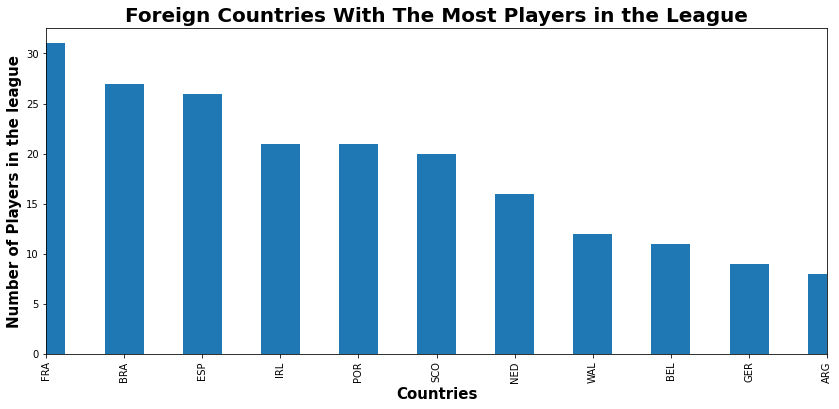

```python
# Plot barchart
plt.figure(figsize=(14,6))
non_eng_plot.plot(kind='bar')
plt.xlim(0,10)
plt.title('Foreign Countries With The Most Players in the League',fontsize=20, fontweight='bold')
plt.xlabel('Countries', fontsize=15, fontweight='bold')
plt.ylabel('Number of Players in the league', fontsize=15, fontweight='bold')
plt.show()
```

- From the chart above, we observe that France has the most foreign players in the league, followed by brazil and then spain.

### Research Question 3: The teams with the worst disciplinary record.

> This question will be addressed through the following steps:
> - Extract the clubs with poor displinary records.
> - Plot a barchart showing the teams with poor displinary records.

```python
# find the amount of yellow cards each club received and sort in descending order
yel_crd = df.groupby('Club')['Yellow_Cards'].sum().sort_values(ascending=False)
```

```python
yel_crd
```

```
Club
Sheffield United           73
Aston Villa                71
Fulham                     67
Newcastle United           65
Manchester United          64
Leeds United               61
Leicester City             61
Everton                    59
Tottenham Hotspur          57
Crystal Palace             56
Wolverhampton Wanderers    55
Southampton                52
West Bromwich Albion       51
Chelsea                    51
West Ham United            50
Arsenal                    49
Brighton                   49
Burnley                    48
Manchester City            46
Liverpool FC               40
Name: Yellow_Cards, dtype: int64
```

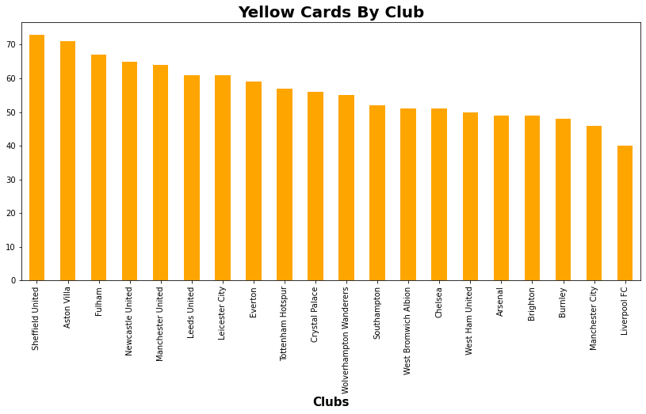

```python
# Plot barchart
plt.figure(figsize=(14,6))
yel_crd.plot(kind='bar', color='orange')
plt.title('Yellow Cards By Club',fontsize=20, fontweight='bold')
plt.xlabel('Clubs', fontsize=15, fontweight='bold')
plt.show()
```

- From the chart above, we can see that the players for Sheffield United and Aston villa received the most yellow cards during the season. We also observe that players for Manchester city and Liverpool received the least amount of yellow cards during the season.

```python
# find the amount of red cards each club received and sort in descending order
red_crd = df.groupby('Club')['Red_Cards'].sum().sort_values(ascending=False)
```

```python
red_crd
```

```
Club
Brighton                   6
Arsenal                    5
West Bromwich Albion       4
Aston Villa                4
Sheffield United           3
West Ham United            3
Chelsea                    3
Fulham                     3
Southampton                3
Newcastle United           3
Crystal Palace             2
Everton                    2
Tottenham Hotspur          2
Manchester City            2
Wolverhampton Wanderers    1
Manchester United          1
Leeds United               1
Leicester City             0
Burnley                    0
Liverpool FC               0
Name: Red_Cards, dtype: int64
```

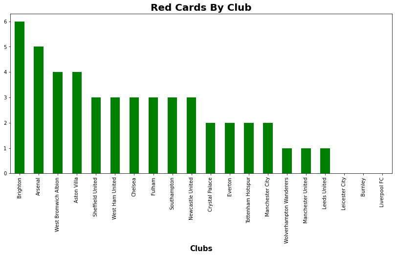

```python
# Plot barchart
plt.figure(figsize=(14,6))
red_crd.plot(kind='bar', color='green')
plt.title('Red Cards By Club',fontsize=20, fontweight='bold')
plt.xlabel('Clubs', fontsize=15, fontweight='bold')
plt.show()
```

- From the chart above, we observe that Brighton and Arsenal received the most red cards, while no player from Leicester, Burnley and liverpool receievd a red card.

### Research Question 4: Which outfield players played the most minutes.

> This question will be addressed through the following steps:
> - Extract all outfield(non GK) players into a new dataframe.
> - Extract the players with the most playing time for the season.
> - plot a graph showing the top ten players with that played the most minutes.

```python
# Extract all outfield(non GK) players into a new dataframe called 'out_fld'
out_fld = df[df.Position!='GK']
```

```python
# find the players with the highest number of minutes played
out_fld.groupby('Name')['Mins'].mean().sort_values(ascending=False)
```

```
Name
James Ward-Prowse         3420.0
Pierre Højbjerg           3420.0
Tomáš Souček              3419.0
Ashley Westwood           3410.0
Stuart Dallas             3409.0
                           ...
Jayson Molumby               1.0
William Thomas Fish          1.0
Femi Seriki                  1.0
Dane Scarlett                1.0
Jaden Philogene Bidace       1.0
Name: Mins, Length: 483, dtype: float64
```

```python
# create a variable for players with highest number of minutes played
Min_high = out_fld.groupby('Name')['Mins'].mean().sort_values(ascending=False)
```

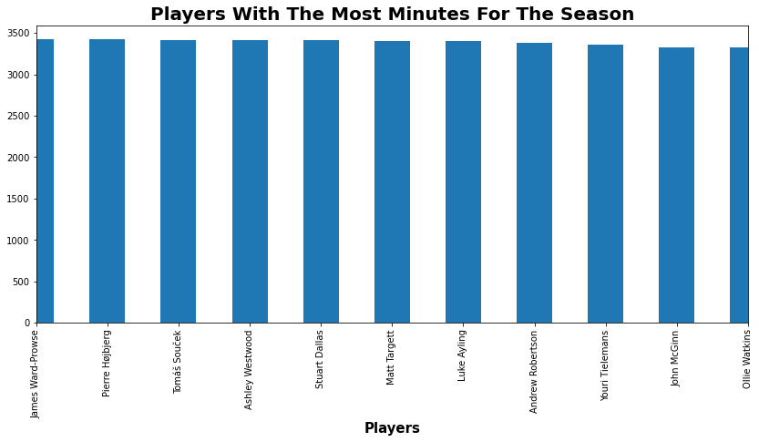

```python
# plot a graph showing the top ten players with that played the most minutes.
plt.figure(figsize=(14,6))
Min_high.plot(kind='bar')
plt.xlim(0,10)
plt.title('Players With The Most Minutes For The Season',fontsize=20, fontweight='bold')
plt.xlabel('Players', fontsize=15, fontweight='bold')
plt.show()
```

### Research Question 5: Which teams received the most penalties.

```python
# Extract the number of penalties awarded to each club in descending order
pen_ard = df.groupby('Club')['Penalty_Attempted'].sum().sort_values(ascending=False)
```

```python
pen_ard
```

```
Club
Leicester City             12
Manchester United          11
Chelsea                    10
Brighton                    9
Manchester City             9
Newcastle United            7
Arsenal                     6
Southampton                 6
Aston Villa                 6
Liverpool FC                6
Fulham                      6
Everton                     5
Tottenham Hotspur           5
Leeds United                4
Crystal Palace              4
Sheffield United            4
West Bromwich Albion        4
West Ham United             4
Wolverhampton Wanderers     4
Burnley                     3
Name: Penalty_Attempted, dtype: int64
```

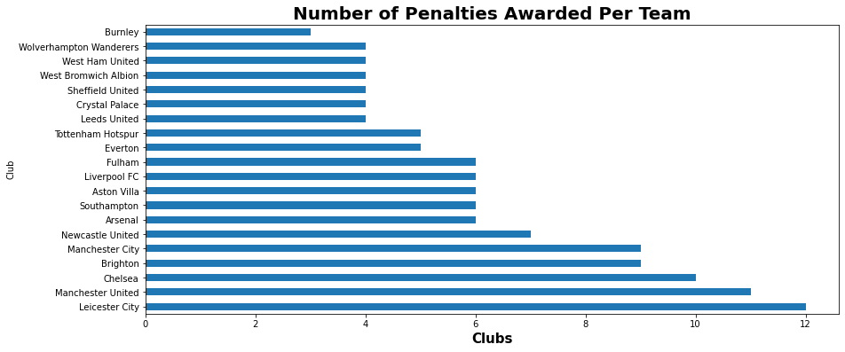

```python
# Plot chart
plt.figure(figsize=(14,6))
pen_ard.plot(kind='barh')
plt.title('Number of Penalties Awarded Per Team',fontsize=20, fontweight='bold')
plt.xlabel('Clubs', fontsize=15, fontweight='bold')
plt.show()
```

- From the chart above, we observe that Leicester city was awarded the most penalties for the season in comparison to Burnley that was awareded the least number of penalties for the season.

```python
# Extract the number of penalties scored by each club in descending order
pen_scrd = df.groupby('Club')['Penalty_Goals'].sum().sort_values(ascending=False)
```

```python
pen_scrd
```

```
Club
Leicester City             10
Manchester United          10
Chelsea                     8
Arsenal                     6
Newcastle United            6
Liverpool FC                6
Brighton                    6
Aston Villa                 5
Manchester City             5
Southampton                 5
Tottenham Hotspur           5
Everton                     4
Leeds United                4
West Bromwich Albion        4
Wolverhampton Wanderers     4
Fulham                      3
Crystal Palace              3
Burnley                     3
Sheffield United            3
West Ham United             2
Name: Penalty_Goals, dtype: int64
```

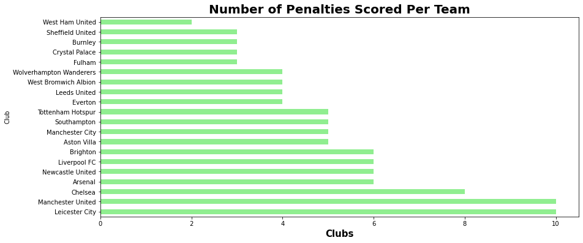

```python
# Plot chart
plt.figure(figsize=(14,6))
pen_scrd.plot(kind='barh', color='lightgreen')
plt.title('Number of Penalties Scored Per Team',fontsize=20, fontweight='bold')
plt.xlabel('Clubs', fontsize=15, fontweight='bold')
plt.show()
```

```python
# Penalty conversion rate
pen_con = (pen_scrd/pen_ard)*100
```

```python
pen_con.sort_values(ascending=False)
```

```
Club
Arsenal                    100.000000
Leeds United               100.000000
West Bromwich Albion       100.000000
Tottenham Hotspur          100.000000
Liverpool FC               100.000000
Burnley                    100.000000
Wolverhampton Wanderers    100.000000
Manchester United           90.909091
Newcastle United            85.714286
Leicester City              83.333333
Aston Villa                 83.333333
Southampton                 83.333333
Everton                     80.000000
Chelsea                     80.000000
Crystal Palace              75.000000
Sheffield United            75.000000
Brighton                    66.666667
Manchester City             55.555556
Fulham                      50.000000
West Ham United             50.000000
dtype: float64
```

> From the analysis and plots above we notice the folowing:
> - **Leicester City** were awarded the most penalties with 12.
> - Although **Leicester City** were awarded the most penalties with 12, they were only able to convert 10 of them, leaving them with a penalty convertion rate of 83%.
> - Interestingly enough, **Manchester city** were awarded 9 penalties but only managed to convert 5 of them, leaving them with a convertion rate of about 56%, one of the lowest in the league.

# Conclusion

I gained the following insights from the analysis above:

- Manchester United had the youngest squad with an average age of 23.86, roughly 24 years.
- Crystal palace had the oldest squad with an average age of 28.33 roughly 28 years.
- France had the most foreign players in the league, followed by brazil and then spain.
- Players for Sheffield United and Aston villa received the most yellow cards during the season.
- Players for Manchester city and Liverpool received the least amount of yellow cards during the season.
- James Ward-Prowse and Pierre Hojbjerg had the highest number of minutes with 3420. Both these players played every single minute of the 20/21 EPL season.
- Leicester city was awarded the most penalties for the season in comparison to Burnley that was awareded the least number of penalties for the season.
- Manchester city were awarded 9 penalties but only managed to convert 5 of them, leaving them with a convertion rate of about 56%, one of the lowest in the league.

# Limitation

It is important to note that that the conclusions derived from the analysis above are only exclusive to the EPL 20/21 season. Therefore the information derived from this analysis does not apply to other seasons of the EPL.

## Glossary

- **EPL** -: English Premier League
- **Perc_Passes_Completed** -: Percentage of passes completed
- **xG** -: expected Goals per game
- **xA** -: expected assists per game